# Hands-on training session 6

Meta-analyses with imperfect reference test

Paolo Eusebi

2020-02-21

# Introduction

## Overview

Date/time:

- 20th February 2020
- 16.00 - 17.00

Teachers:

- Paolo Eusebi (presenter)
- Giles Innocent

## Recap

- Important points from previous sessions

# Session 6a: Meta-Analysis of Diagnostic Test Accuracy Studies: Perfect Reference Test

## DTA-MA: perfect reference test

- There is an increasing interest in meta-analyzing data from diagnostic accuracy studies
- The data from the primary studies are summarized in a 2-by-2 cross-tabulation of the dichotomized test result against the true disease status (assuming we have a perfect reference test)

|  | D+ | D- |
| --- | --- | --- |
| T+ | TP | FP |
| T- | FN | TN |

## DTA-MA: perfect reference test

- Data on magnetic resonance (MR) imaging from 10 studies on evaluation of lymph node metastases in patients with cervical cancer (Scheidler et al 1997).

| StudyID | TP | FP | FN | TN |
| --- | --- | --- | --- | --- |
| Study 1 | 9 | 2 | 2 | 44 |
| Study 2 | 3 | 6 | 5 | 32 |
| Study 3 | 3 | 2 | 1 | 16 |
| Study 4 | 3 | 1 | 12 | 44 |
| Study 5 | 1 | 1 | 6 | 16 |
| Study 6 | 7 | 2 | 22 | 167 |
| Study 7 | 12 | 4 | 4 | 29 |
| Study 8 | 23 | 5 | 14 | 230 |
| Study 9 | 8 | 5 | 5 | 53 |
| Study 10 | 16 | 2 | 2 | 22 |

## DTA-MA: perfect reference test

- Forest plot of sensitivity

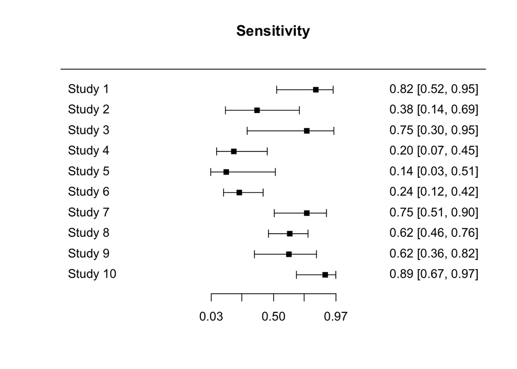

## DTA-MA: perfect reference test

- Forest plot of specificity

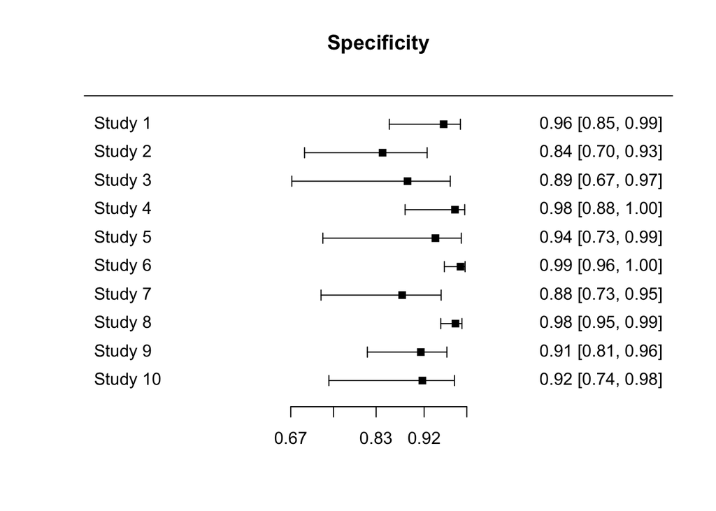

## DTA-MA: perfect reference test

- Data points with confidence ellipses on a ROC space

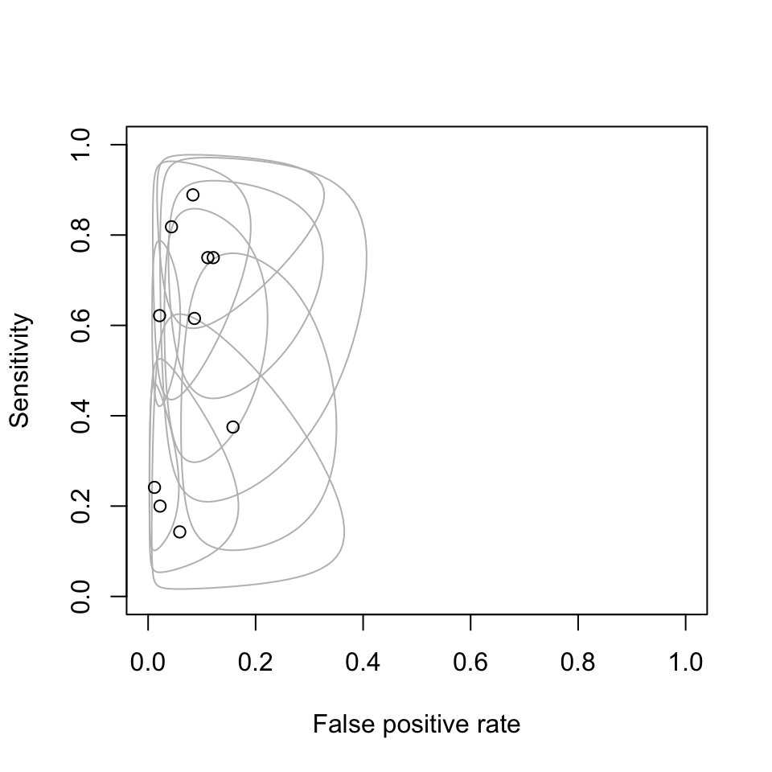

## DTA-MA: perfect reference test

Two main frameworks:

- Hierarchical Summary ROC (Rutter and Gatsonis 2001)
- Bivariate analysis of sensitivity and specificity (Reitsma et al. 2005)

## DTA-MA: bivariate analysis of sensitivity and specificity

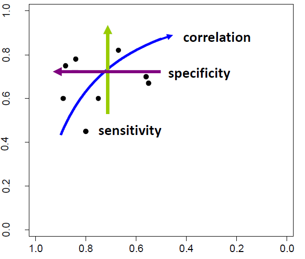

## DTA-MA: hierarchical summary ROC (HSROC)

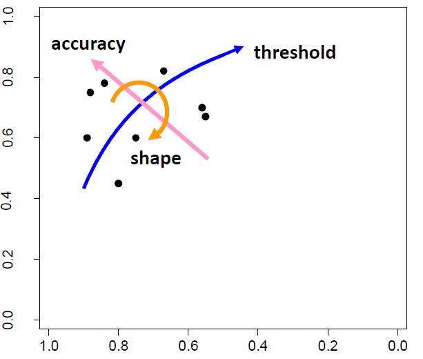

## DTA-MA: bivariate analysis of sensitivity and specificity

Some notation/definitions (no covariates)

$$(\mu_{A_i} \mu_{B_i}) \sim N((\mu_A \mu_B), \Sigma_{AB})$$

with

$$\Sigma_{AB} = \begin{pmatrix}
\sigma^2_A & \sigma^2_{AB} \\\
\sigma^2_{AB} & \sigma^2_B
\end{pmatrix}$$

$\mu_{A_i}$ is the logit-transformed sensitivity in study $i$ $\mu_{B_i}$ is the logit-transformed specificity in study $i$

## DTA-MA: hierarchical summary ROC (HSROC)

Some notation/definitions (no covariates)

- level I (within study)

$logit(\pi_{ij})=(\theta_i + \alpha_i D_{ij}) \cdot exp(-\beta \cdot D_{ij})$

- level II (between studies)

$\theta_i \sim N(\Theta, \sigma^2_\theta)$

$\alpha_i \sim N(\Lambda, \sigma^2_\alpha)$

$\theta_i$ are cutpoint parameters (or positivity criteria)

$\alpha_i$ are accuracy parameters

$\beta$ is a shape parameter, allowing true-positive and false-positive fractions to increase at different rates as $\theta_i$ increases

## DTA-MA: bivariate analysis of sensitivity and specificity

Let’s run the model with reitsma function (mada R package)

```r
fit.reitsma <- reitsma(MRI2)
print(summary(fit.reitsma), digits = 2)
```

```
## Call:  reitsma.default(data = MRI2)
##
## Bivariate diagnostic random-effects meta-analysis
## Estimation method: REML
##
## Fixed-effects coefficients
##                   Estimate Std. Error     z Pr(>|z|)
## tsens.(Intercept)     0.23       0.39  0.59     0.55
## tfpr.(Intercept)     -2.80       0.32 -8.64     0.00
## sensitivity           0.56          -     -        -
## false pos. rate       0.06          -     -        -
##                   95%ci.lb 95%ci.ub
## tsens.(Intercept)    -0.53     0.99
## tfpr.(Intercept)     -3.44    -2.17 ***
## sensitivity           0.37     0.73
## false pos. rate       0.03     0.10
## ---
## Signif. codes:  0 '***' 0.001 '**' 0.01 '*' 0.05 '.' 0.1 ' ' 1
##
## Variance components: between-studies Std. Dev and correlation matrix
##       Std. Dev tsens tfpr
## tsens     1.02  1.00    .
## tfpr      0.79  0.55 1.00
##
## logLik    AIC    BIC
##  18.26 -26.52 -21.54
##
## AUC:  0.908
## Partial AUC (restricted to observed FPRs and normalized):  0.618
##
## HSROC parameters
##       Theta      Lambda        beta sigma2theta sigma2alpha
##       -1.50        3.40       -0.26        0.62        0.72
```

## DTA-MA: bivariate analysis of sensitivity and specificity

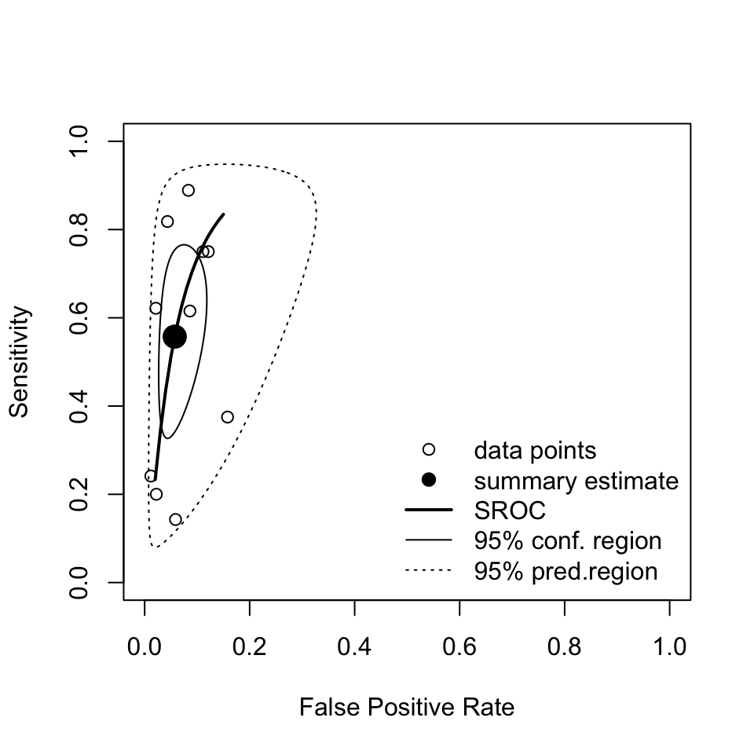

## DTA-MA: bivariate analysis of sensitivity and specificity

- Where is the summary measure of heterogeneity?
- There is $I^2$ for DTA-MA?

## DTA-MA: bivariate analysis of sensitivity and specificity

The function returns also HSROC parameters

```r
print(summary(fit.reitsma)[20], digits = 2)
```

```
## $coef_hsroc
## $coef_hsroc$Theta
## [1] -1.5
##
## $coef_hsroc$Lambda
## [1] 3.4
##
## $coef_hsroc$beta
## [1] -0.26
##
## $coef_hsroc$sigma2theta
## [1] 0.62
##
## $coef_hsroc$sigma2alpha
## [1] 0.72
```

## DTA-MA: bivariate analysis of sensitivity and specificity

This is because Bivariate and HSROC approaches are equivalent when covariates are not included (Harbord et al. 2007)

- Parameter estimates from either model can be used to produce a summary operating point, an SROC curve, confidence regions, or prediction regions.
- The choice between these parameterizations depends partly on the degrees of and reasons for between-study heterogeneity and the treshold effect.

## DTA-MA: hierarchical summary ROC (HSROC)

Use of HSROC package

```r
HSROC(data = MRI,
      iter.num = 5000,
      init = init)

HSROCSummary(data = MRI,
             burn_in = 1000,
             print_plot = T)
```

## DTA-MA: hierarchical summary ROC (HSROC)

- The HSROC package allows to run multiple chains
- A single call to the function HSROCSummary will summarize all chains (3 in our example)

```r
HSROC(data = MRI,
      iter.num = 5000,
      init = init,
      chain = dir.chain1)

HSROCSummary(data = MRI,
             burn_in = 1000,
             print_plot = T,
             chain = list(dir.chain1, dir.chain2, dir.chain3))
```

## DTA-MA: imperfect reference test(s)

Why?

- Ignoring the imperfect nature of the reference may result in biased estimates of pooled sensitivity and specificity of the test under evaluation

## DTA-MA: imperfect reference test(s)

How?

- Multivariate generalized linear mixed model (MGLMM)
- Hierarchical summary receiver operating characteristic (HSROC)
- Exact relations between the parameters of these models can be provided.
- But some submodels of the MGLMM do not have corresponding equivalent submodels of the HSROC model, and vice versa.

## DTA-MA: HSROC for imperfect reference test(s)

Dendukuri et al. Biometrics. 2012

- The data from the primary studies are summarized in a 2-by-2 cross-tabulation of the index test ($T_1$) result against the imperfect refernce ($T_2$)

|  | T2+ | T2- |
| --- | --- | --- |
| T1+ | TP | FP |
| T1- | FN | TN |

The sensitivity and the specificity of the reference test are defined as:

- $S_2 = P(T_2=+|D+)$
- $C_2 = P(T_2=-|D-)$

## DTA-MA: discussion

- Comments?
- Questions?
- Ideas?

## DTA-MA: hierarchical summary ROC (HSROC)

Let’s do it with rjags

## Exercise

Use Timsit paper data (Prev Vet Med 2016)

| StudyID | TP | FP | FN | TN |
| --- | --- | --- | --- | --- |
| Gardner | 49 | 53 | 38 | 64 |
| Buhman | 37 | 1 | 90 | 18 |
| Thompson | 265 | 196 | 606 | 969 |
| Schneider | 121 | 42 | 910 | 592 |
| Leach | 195 | 60 | 1395 | 373 |
| Tennant | 157 | 29 | 1344 | 806 |
| Rezac | 127 | 157 | 4591 | 8316 |

1. Fit a bivariate model assuming perfect reference with reitsma() in mada
2. Fit a HSROC model assuming imperfect reference with HSROC() in HSROC
3. Fit a HSROC model assuming imperfect reference with model definitions in rjags